## Оптическое распознавание символов

**Особенности материала**:

1. Взаимная конвертация файлов в форматах PDF и PNG.
2. Взаимосвязь библиотек:
   - **pdftools** (для работы с pdf-файлами),
   - **magick** (для работы с изображениями),
   - **tesseract** (для распознавания символов).
3. Обработка файлов с двумя колонками.
4. Улучшение качества распознавания.

**Оптическое распознавание символов** (или Optical Character Recognition, OCR) – это процесс преобразования изображения текста в машиночитаемый текстовый формат. Другими словами, процедура отслеживает вариации пикселей на изображении страниц и переводит его в цифровой вид. Необходимость использовать OCR возникает в случае извлечения текстовых данных из изображений. Наиболее часто используемые форматы входных файло для распознавания – это PDF и PNG.

Наиболее практичные пакеты для работы с pdf-файлами – `pdftools` (поддерживает высококачественный рендеринг pdf-файлов в форматы PNG, JPEG, TIFF либо растры), с изображениями – `magick` (самая полная из доступных библиотек обработки изображений). Для распознавания текста с изображений нужен пакет `tesseract`, фактически он и делает всю работу.

Загружаем необходимые библиотеки

```r
library(pdftools)
library(magick)
library(tesseract)
library(stringr)
library(magrittr)
```

Для чтения pdf-файлов служит функция `pdf_text()`. Если файл создан по-человечески, то она извлечет текст без запуска OCR. Если же возвращает пустые строки, то тогда нужно распознавание. Можно сделать с помощью функции `pdf_ocr_text()`, она под капотом использует `tesseract::ocr()`. Технически можно перевести изображение из формата .png в формат .pdf. Сначала считав изображение через `magick::image_read()`, затем сохранив его через `magick::image_write()`.

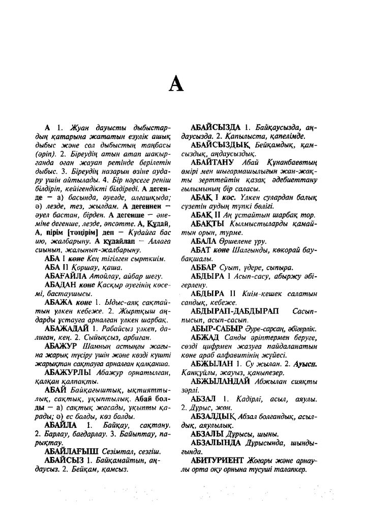

```r
# можем читать и отличный от PNG формат
png_to_pdf <- magick::image_read("Kaz_dict.jpg")
magick::image_write(image = png_to_pdf, format = "pdf", path = "png_to_pdf.pdf")
png_to_pdf
```

Видим, что наша картинка – это скан первой страницы из толкового словаря казахского языка.

При попытке чтения через `pdf_text()` получаем пустую строку. Причина в том, что pdf-файл сделан из изображения. Распространенный вариант – это отсканированные документы, сохраненные как PDF.

```r
pdftools::pdf_text(pdf = "png_to_pdf.pdf")
```

```
## [1] ""
```

Если же используем распознавание pdf-файла, то получим результат.

```r
pdftools::pdf_ocr_text(pdf = "png_to_pdf.pdf")
```

```
## Converting page 1 to png_to_pdf_1.png... done!
```

```
## [1] "A 1. Xyaxn dayticmb dothbicmap- ABAMCBIZIA |. Baiixaycw3da, an-\ndoin Kamapbikta x#camambn exyaik auwk, Oaycoizda. 2. Kanoiisicma, Kaneaimde.\ndpderc wave con GhObicmpiH manbacol ABAMCHI3JIBIK Sedxamden, Kam-\nfapin). 2. Bipeydiq amok aman uianbip- coi3zdbiK, AN@aycolz0dlK.\neaqnda ozan ocay…
```

Обращаем внимание на сообщение `## Converting page 1 to png_to_pdf_1.png... done!`. Это значит, что функция сконвертировала pdf-файл в png, так как под капотом `pdf_ocr_text()` использует функцию `pdf_convert()`.

Как видно, результат распознавания не совсем такой как ожидалось. Дело в том, что по умолчанию в `pdf_ocr_text()` используется параметр `language = "eng"`. Нам необходим параметр для казахского языка. Страница, где можно поискать доступные для распознавания языки находится [здесь](https://github.com/tesseract-ocr/tessdoc/blob/main/Data-Files-in-different-versions.md). Очевидно, что нам нужен параметр `language = "kaz"`. Однако нам нужно предварительно скачать обучающие данные для выполнения распознавания казахского языка.

```r
tesseract_download("kaz")
```

Проверяем доступные языки.

```r
tesseract_info()$available
```

```
## [1] "eng" "kaz" "osd" "rus"
```

Далее распознаем текст.

```r
text_image <- ocr(image = png_to_pdf, engine = "kaz")
text_image
```

```
## [1] "А 1. Жуан дауысты дыбыстар- АБАЙСЫЗДА 1. Байқаусызда, аң-\nдың қатарына жататын езулік ашық даусызда. 2. Қапылыста, қапелімде.\nдыбыс және сол дыбыстың таңбасы АБАЙСЫЗДЫҚ, Бейқамдық, қам-\n(әріп). 2. Біреудің атын атап шақыр- сыздық, аңдаусыздық.\nғанда оған жауап ретінде берілетін АБАЙТАНУ …
```

Как видим, казахский язык распознался. Однако в силу того, что изображение содержит два столбца, получается абракадабра. Для того, чтобы разделить столбцы и считать текст правильно, добавим параметр в механизм распознавания `tessedit_pageseg_mode = 1`. Список всех параметров можно получить, вызвав в консоли `tesseract_params()` (на сентябрь 2022 всего 625 параметров). Можно осуществлять поиск параметров, например, `tesseract_params(filter = "tessedit")` и смотреть их описание, например, `tesseract_params("tessedit_ocr_engine_mode")$desc`.

```r
kaz <- tesseract(language = "kaz", options = list(tessedit_pageseg_mode = 1))
text_image <- ocr(image = png_to_pdf, engine = kaz)
text_image
```

```
## [1] "А\n\nА 1. Жуан дауысты дыбыстар-\nдың қатарына жататын езулік ашық\nдыбыс және сол дыбыстың таңбасы\n(әріп). 2. Біреудің атын атап шақыр-\nғанда оған жауап ретінде берілетін\nдыбыс. 3. Біреудің назарын өзіне ауда-\nру үшін айтылады. 4. Бір нәрсеге реніш\n\nдікті білдіреді. А деген-\nде- - а)…
```

Сделаем небольшую обработку текста: убирем знаки абзаца и переноса на другую строку.

```r
text_image %>%
  str_replace_all(., "-\\n", "") %>%
  str_squish()
```

```
## [1] "А А 1. Жуан дауысты дыбыстардың қатарына жататын езулік ашық дыбыс және сол дыбыстың таңбасы (әріп). 2. Біреудің атын атап шақырғанда оған жауап ретінде берілетін дыбыс. 3. Біреудің назарын өзіне аудару үшін айтылады. 4. Бір нәрсеге реніш дікті білдіреді. А дегенде- - а) басында, әуелде, алғ…
```

Таким образом, мы получаем более-менее приличный результат c параметрами обработки изображений “из коробки”. Возможные сложности – неточность распознавания, особенно, если есть диакритические знаки, как здесь. Точность процесса OCR зависит от качества входного изображения. Часто можете улучшить результаты, правильно масштабируя изображение, удаляя шум и артефакты или обрезая область, где есть текст. Следует помнить, что `tesseract` лучше всего работает с изображениями с разрешением не менее 300 точек на дюйм. Это можно сделать через параметр `dpi` функции `pdf_convert()`.

Также полезным параметром является параметр `tessedit_char_whitelist`. Ценен тем, что позволяет распознавать текстовые данные в рамках заданных символов. Например, нужно распознать только цифры.

```r
only_numbers <- tesseract(options = list(tessedit_char_whitelist = ".0123456789"))
print(ocr(png_to_pdf, engine = only_numbers))
```

```
## [1] "1.6 31. 3\n3.2...\n66 3\n.2.3030.\n26 66\n.3.32\n.4.30\n6..2.\n46. .6\n82302.30.36.\n6.. 46..\n0.\n26.\n. .\n.. 06\n\n. 6.\n\n. .\n\n. 6\n\n2.\n\n.\n1..0.6.\n\n.2.\n\n6...\n1. .\n\n.2.36. 6\n3032\n\n30.\n\n2. 1..2..\n.\n\n.\n.\n\n..0 31...\n\n42...\n\n803. 362\n1.....\n\n2..6.3. 3.\n\n. 30\n…
```

В данном случае алгоритм OCR распознает букву б как 6, букву з как 3 и т.п.

Для более подробного ознакомления с `tesseract` можно воспользоваться соответствующим [руководством](https://tesseract-ocr.github.io/tessdoc/).